# Statistical inference with the GSS data

## Setup

### Load packages

```r
library(ggplot2)
library(dplyr)
library(statsr)
```

### Load data

Make sure your data and R Markdown files are in the same directory. When loaded your data file will be called `gss`. Delete this note when before you submit your work.

```r
load("gss.Rdata")
```

## Part 1: Data

According to the GSS website, data was collected from random sampling of all noninstitutionalized, English and Spanish speaking persons 18 years of age or older, living in the United States. Interview was conducted through computer (CAPI),face-to-face, or telephone.

Analysis based on the current data set should be fairly generalizable to the English-speaking and Spanish-speaking non-institutionalized individuals. It is possible that the analysis might contain bias as the data set does not include information of non-English-speaking, non-Spanish-speaking population, which constitute significant part of the US population. It also misses data from a considerable amount of expat (US citizens working abroad) that do not reside in US at the time when interviews were conducted.

Any conclusion derived from the current data set does not imply causality, only correlational. It was not a controlled experiment. * * *

## Part 2: Research question

Research question: What is high income proportion among people with different degrees? In other words, for people without a highschool degree, with a highschool degree, with a junior college, a bachelor degree and graudate school degree, will there be a difference in the proportion of high income population among these different groups?

The question is of interest as it will show us whether education could be an indicator of income and a divider for social equity.

variables of interest: degree, income06 (*high income is define as >$75000 annual family income)

## Part 3: Exploratory data analysis

3 pts for summary statistics  
Summary statistics should address the research questions (1 pt)  
Summary statistics should be calculated correctly (1 pt)  
Summary statistics should be formatted well – not taking up pages and pages, etc. (1 pt)

Create a subset for analysis, to address the research question:

```r
q1 <- gss%>%
  filter(!is.na(income06)) %>%
  filter(!(income06 == "Refused")) %>%
  filter(!is.na(degree)) %>%
  select(caseid, degree, income06)

q1 <- q1 %>%
  mutate(high_income = ifelse(income06 == "$75000 To $89999" | income06 == "$90000 To $109999" |income06 == "$110000 To $129999" | income06 == "$130000 To $149999" | income06 == "$150000 Or Over", "yes", "no"))
```

Data summary:  
1. Counts of individuals in different degree categories

```r
summary(q1$degree)
```

```
## Lt High School    High School Junior College       Bachelor       Graduate
##           1240           4595            741           1661            921
```

2. Percentage of the population at each income level

```r
table2 <- table(q1$income06)
prop.table(table2)
```

```
##
##       Under $1 000    $1 000 To 2 999    $3 000 To 3 999    $4 000 To 4 999
##        0.013758463        0.012120550        0.009281503        0.005678096
##    $5 000 To 5 999    $6 000 To 6 999    $7 000 To 7 999    $8 000 To 9 999
##        0.009063114        0.011356191        0.013430880        0.020746888
##    $10000 To 12499    $12500 To 14999    $15000 To 17499    $17500 To 19999
##        0.038982311        0.034286962        0.033413409        0.025005460
##    $20000 To 22499    $22500 To 24999    $25000 To 29999    $30000 To 34999
##        0.037453592        0.035924874        0.052085608        0.056234986
##    $35000 To 39999    $40000 To 49999    $50000 To 59999    $60000 To 74999
##        0.053505132        0.091177113        0.080039310        0.097073597
##   $75000 To $89999  $90000 To $109999 $110000 To $129999 $130000 To $149999
##        0.075671544        0.061476305        0.041384582        0.025879013
##    $150000 Or Over            Refused
##        0.064970518        0.000000000
```

3. If we define high income as >= $75000, percentage of high-income and non-high-income popualtion:

```r
table3 <- table(q1$high_income)
prop.table(table3)
```

```
##
##       no      yes
## 0.730618 0.269382
```

3 pts for plots  
Plots should address the research questions (1 pt)  
Plots should be constructed correctly (1 pt)  
Plots should be formatted well – size not too large, not too small, etc. (1 pt)

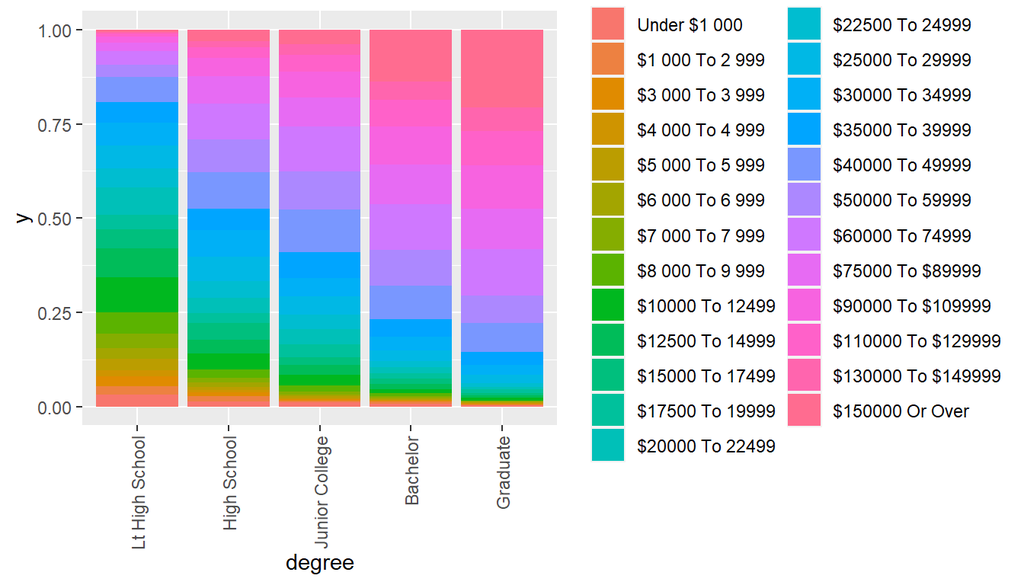

```r
ggplot(q1, aes(fill=income06, y = 1, x=degree)) +
    geom_bar(position = position_fill(reverse = TRUE), stat="identity", width = 0.9) + theme(axis.text.x = element_text(angle = 90, hjust = 1, vjust = .5))
```

According to a study by PNAS, emotional well-being rises with log income and continues until an annual income of $75,000, beyond which the effect dims off. (Kahneman, D., & Deaton, A. (2010). High income improves evaluation of life but not emotional well-being. Proceedings of the national academy of sciences, 107(38), 16489-16493.)

Hence, if we define high-income as family annual income >= $75000, the following bar plot shows a percentage of high-income family of each degree category.

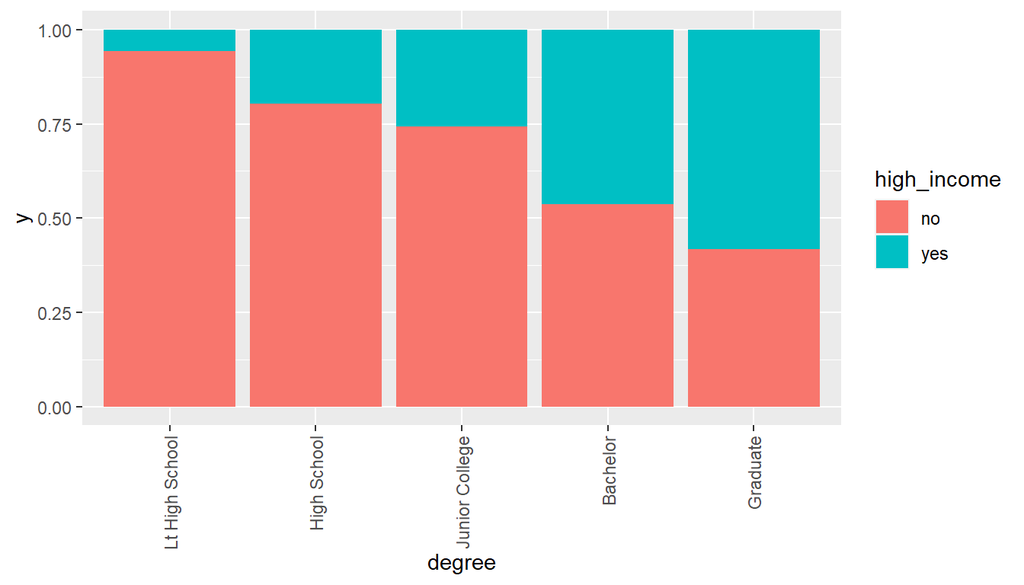

```r
ggplot(q1, aes(fill=high_income, y = 1, x=degree)) +
    geom_bar(position = position_fill(reverse = TRUE), stat="identity", width = 0.9) + theme(axis.text.x = element_text(angle = 90, hjust = 1, vjust = .5))
```

4 pts for narrative  
Each plot and/or R output should be accompanied by a narrative (1 pt)  
Narrative should interpret the visuals / R output correctly (1 pts)  
Narrative should address the research question (2 pts)

## Part 4: Inference

```r
inference(y=high_income, x=degree, data = q1, statistic = "proportion", type = "ht", null = 0, alternative = "greater", method = "theoretical", success = "atheist")
```

```
## Response variable: categorical (2 levels)
## Explanatory variable: categorical (5 levels)
## Observed:
##                 y
## x                  no  yes
##   Lt High School 1169   71
##   High School    3696  899
##   Junior College  550  191
##   Bachelor        892  769
##   Graduate        384  537
##
## Expected:
##                 y
## x                       no       yes
##   Lt High School  905.9664  334.0336
##   High School    3357.1899 1237.8101
##   Junior College  541.3880  199.6120
##   Bachelor       1213.5566  447.4434
##   Graduate        672.8992  248.1008
##
## H0: degree and high_income are independent
## HA: degree and high_income are dependent
## chi_sq = 1187.6643, df = 4, p_value = 0
```

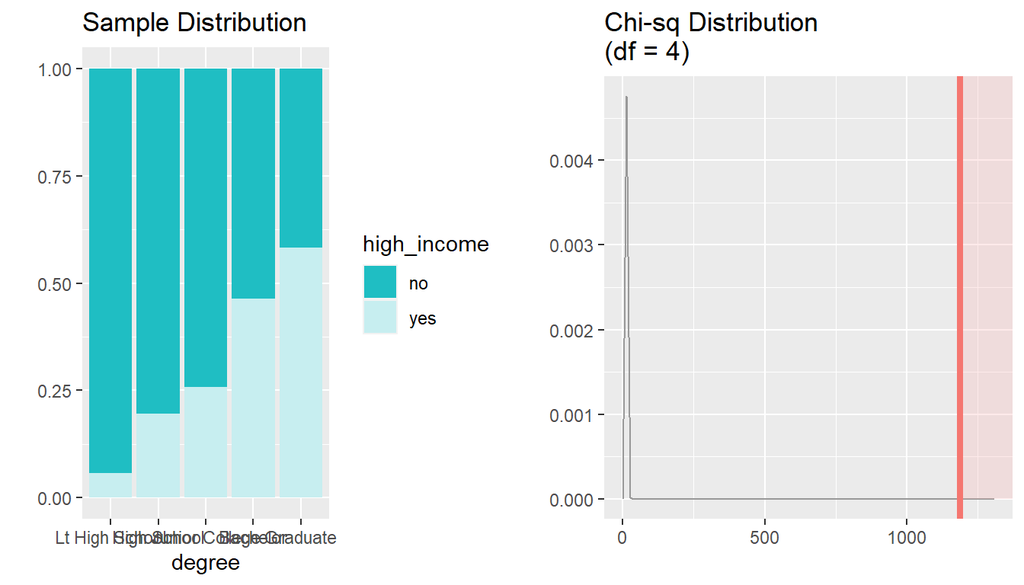

According to the above hypothesis test, we can almost be certain that degree and high_income are dependent.